# Project Python Foundations: FoodHub Data Analysis

### Context

The number of restaurants in New York is increasing day by day. Lots of students and busy professionals rely on those restaurants due to their hectic lifestyles. Online food delivery service is a great option for them. It provides them with good food from their favorite restaurants. A food aggregator company FoodHub offers access to multiple restaurants through a single smartphone app.

The app allows the restaurants to receive a direct online order from a customer. The app assigns a delivery person from the company to pick up the order after it is confirmed by the restaurant. The delivery person then uses the map to reach the restaurant and waits for the food package. Once the food package is handed over to the delivery person, he/she confirms the pick-up in the app and travels to the customer's location to deliver the food. The delivery person confirms the drop-off in the app after delivering the food package to the customer. The customer can rate the order in the app. The food aggregator earns money by collecting a fixed margin of the delivery order from the restaurants.

### Objective

The food aggregator company has stored the data of the different orders made by the registered customers in their online portal. They want to analyze the data to get a fair idea about the demand of different restaurants which will help them in enhancing their customer experience. Suppose you are hired as a Data Scientist in this company and the Data Science team has shared some of the key questions that need to be answered. Perform the data analysis to find answers to these questions that will help the company to improve the business.

### Data Description

The data contains the different data related to a food order. The detailed data dictionary is given below.

### Data Dictionary

- order_id: Unique ID of the order
- customer_id: ID of the customer who ordered the food
- restaurant_name: Name of the restaurant
- cuisine_type: Cuisine ordered by the customer
- cost_of_the_order: Cost of the order
- day_of_the_week: Indicates whether the order is placed on a weekday or weekend (The weekday is from Monday to Friday and the weekend is Saturday and Sunday)
- rating: Rating given by the customer out of 5
- food_preparation_time: Time (in minutes) taken by the restaurant to prepare the food. This is calculated by taking the difference between the timestamps of the restaurant's order confirmation and the delivery person's pick-up confirmation.
- delivery_time: Time (in minutes) taken by the delivery person to deliver the food package. This is calculated by taking the difference between the timestamps of the delivery person's pick-up confirmation and drop-off information

### Let us start by importing the required libraries

```python
# Installing the libraries with the specified version.
!pip install numpy==1.25.2 pandas==1.5.3 matplotlib==3.7.1 seaborn==0.13.1 -q --user
```

**Note**: *After running the above cell, kindly restart the notebook kernel and run all cells sequentially from the start again.*

```python
# import libraries for data manipulation
import numpy as np
import pandas as pd

# import libraries for data visualization
import matplotlib.pyplot as plt
import seaborn as sns
```

### Understanding the structure of the data

```python
# uncomment and run the following lines for Google Colab
from google.colab import drive
drive.mount('/content/drive')
```

```python
# Write your code here to read the data
# The pandas read_csv method can be used to read the file into a dataframe.
path="/content/drive/MyDrive/AI-ML Course/Python Foundations/Foodhub/foodhub_order.csv"
data=pd.read_csv(path)
```

```python
# Write your code here to view the first 5 rows
# The head method shows us the first 5 rows of the data.
data.head()
```

|  | order_id | customer_id | restaurant_name | cuisine_type | cost_of_the_order | day_of_the_week | rating | food_preparation_time | delivery_time |
| --- | --- | --- | --- | --- | --- | --- | --- | --- | --- |
| 0 | 1477147 | 337525 | Hangawi | Korean | 30.75 | Weekend | Not given | 25 | 20 |
| 1 | 1477685 | 358141 | Blue Ribbon Sushi Izakaya | Japanese | 12.08 | Weekend | Not given | 25 | 23 |
| 2 | 1477070 | 66393 | Cafe Habana | Mexican | 12.23 | Weekday | 5 | 23 | 28 |
| 3 | 1477334 | 106968 | Blue Ribbon Fried Chicken | American | 29.20 | Weekend | 3 | 25 | 15 |
| 4 | 1478249 | 76942 | Dirty Bird to Go | American | 11.59 | Weekday | 4 | 25 | 24 |

Observations

- *We do observe that the rating column has some values as 'Not given'*

### **Question 1:** How many rows and columns are present in the data? [0.5 mark]

```python
# Write your code here
# Using shape attribute to get the number of rows and columns.
# The first attribute is the number of rows and second is the number of columns
data.shape
```

```
(1898, 9)
```

#### Observations:

- *There are 1898 rows and 9 columns in the data*

### **Question 2:** What are the datatypes of the different columns in the dataset? (The info() function can be used) [0.5 mark]

```python
# Write your code here
# The info method gives us the datatypes of the columns
# as well as how many of them are null.
data.info()
```

```
<class 'pandas.core.frame.DataFrame'>
RangeIndex: 1898 entries, 0 to 1897
Data columns (total 9 columns):
 #   Column                 Non-Null Count  Dtype
---  ------                 --------------  -----
 0   order_id               1898 non-null   int64
 1   customer_id            1898 non-null   int64
 2   restaurant_name        1898 non-null   object
 3   cuisine_type           1898 non-null   object
 4   cost_of_the_order      1898 non-null   float64
 5   day_of_the_week        1898 non-null   object
 6   rating                 1898 non-null   object
 7   food_preparation_time  1898 non-null   int64
 8   delivery_time          1898 non-null   int64
dtypes: float64(1), int64(4), object(4)
memory usage: 133.6+ KB
```

- *The columns order_id, customer_id, food_preparation_time, delivery_time are all numerical columns.*
- *The columns restaurant_name, cuisine_type, day_of_the_week, rating are all string columns which show object are string columns.*
- *The column cost_of_the_order is a float column (float64).*
- *We also see that none of the columns have null data.*
- *We also see that rating column which should have been numeric is of object or string datatype. So this column must have some bad data.*

### **Question 3:** Are there any missing values in the data? If yes, treat them using an appropriate method. [1 mark]

```python
# Write your code here
# Checking for null values in columns  using isnull method and summing up for the columns.

print(data.isnull().sum())
```

```
order_id                 0
customer_id              0
restaurant_name          0
cuisine_type             0
cost_of_the_order        0
day_of_the_week          0
rating                   0
food_preparation_time    0
delivery_time            0
dtype: int64
```

- *Running isnull().sum() on the dataset and found that none of its values are null.*
- *So there are no null values in the dataset.*

```python
# While running head in question No.2, and from running info method, we found that
# some of the values in rating column shows as not given
# and because of this rating which is a numerical column shows object as data type.

# Running value_counts function to get an idea of the values in this column
# with dropna=false to get the count of nan values also.
print(data['rating'].value_counts(dropna=False))

# Getting percentage counts for the values of rating
print("\nPercentage count:")
print(data['rating'].value_counts(dropna=False, normalize=True))
```

```
rating
Not given    736
5            588
4            386
3            188
Name: count, dtype: int64

Percentage count:
rating
Not given    0.387777
5            0.309800
4            0.203372
3            0.099052
Name: proportion, dtype: float64
```

- *We observe that for the column rating 736 values which used to be 'Not given'.*
- *Since this is 38% of the data, we dont want to delete these rows as that would be a large percent of data that we would lose if we remove those rows.*
- *We also dont want to remvove the rating column as it is important in the analysis of this data.*
- *So I would like to impute values for this column where rating is not given by doing further analysis on the data we have.*
- *First I'm going to change the 'Not given' values to Nan so that I can use this column in further calculations for imputing values.*

```python
# Since rating should be a numeric value - Going to
# replace values with 'Not given' on the rating column with nan
data['rating'] = data['rating'].replace(['Not given'],np.nan)

# Converting the data type to float so that we can use this column in further calculations
data['rating'] = data['rating'].astype(float)

# Checking data type to see if it is float now
print(data.info())
```

```
<class 'pandas.core.frame.DataFrame'>
RangeIndex: 1898 entries, 0 to 1897
Data columns (total 9 columns):
 #   Column                 Non-Null Count  Dtype
---  ------                 --------------  -----
 0   order_id               1898 non-null   int64
 1   customer_id            1898 non-null   int64
 2   restaurant_name        1898 non-null   object
 3   cuisine_type           1898 non-null   object
 4   cost_of_the_order      1898 non-null   float64
 5   day_of_the_week        1898 non-null   object
 6   rating                 1162 non-null   float64
 7   food_preparation_time  1898 non-null   int64
 8   delivery_time          1898 non-null   int64
dtypes: float64(2), int64(4), object(3)
memory usage: 133.6+ KB
None
```

- *We see that the rating column is now a float column which will help us in using it for further analysis.*

```python
# Going to check the restaurant counts for rating null
# To check if it is null for one restaurant or if it is across many restaurants.
result = data.loc[data['rating'].isnull(), 'restaurant_name'].value_counts(dropna=False)
print(result)

# Also getting total number of unique restaurants
print(f'\nTotal number of unique restaurants are {data["restaurant_name"].nunique()}')
```

```
restaurant_name
Shake Shack                  86
The Meatball Shop            48
Blue Ribbon Sushi            46
Blue Ribbon Fried Chicken    32
Parm                         29
                             ..
Hiroko's Place                1
Blue Ribbon Brooklyn          1
Zero Otto Nove                1
DuMont Burger                 1
Amy Ruth's                    1
Name: count, Length: 134, dtype: int64

Total number of unique restaurants are 178
```

- *Of the 178 total restaurants, 134 have missing ratings.*
- *The null rating data is not concentrated on one or a few restaurants.*
- *Also want to check if it is one or a few customers who are not giving ratings.*

```python
# Going to check the customer_id column for  null rating.
# To check if it is null for one customer or if it is across many customers.
result = data.loc[data['rating'].isnull(), 'customer_id'].value_counts(dropna=False)
print(result)

# Also getting total number of unique restaurants
print(f'\nTotal number of unique customers is {data["customer_id"].nunique()}')
```

```
customer_id
52832     6
83287     5
97079     4
175290    3
275689    3
         ..
111894    1
211035    1
84457     1
351329    1
149268    1
Name: count, Length: 599, dtype: int64

Total number of unique customers is 1200
```

- *Of the 1200 total unique customers, 599 have not given ratings for some of their orders.*
- *The null rating data is not concentrated or coming from one or few customers.*

```python
# Going to check the cuisine_type column for  null rating.
# To check if it is null for one cuisine_type or if it is across all types of cuisines.
result = data.loc[data['rating'].isnull(), 'cuisine_type'].value_counts(dropna=False)
print(result)

# Also getting total number of unique restaurants
print(f'\nTotal number of unique cuisine_type is {data["cuisine_type"].nunique()}')
```

```
cuisine_type
American          216
Japanese          197
Italian           126
Chinese            82
Mexican            29
Indian             23
Middle Eastern     15
Mediterranean      14
Thai               10
French              8
Spanish             6
Korean              4
Southern            4
Vietnamese          2
Name: count, dtype: int64

Total number of unique cuisine_type is 14
```

- *Of the 14 cuisine types, all of them have null ratings.*
- *The null rating data on a particular cuisine type.*
- *Thinking this further, I think the best way to impute the value for the null ratings is to use the mean or median rating after grouping by restaurant and cuisine type.*
- *Checking if the data is skewed to decide whether to use mean or the median.*

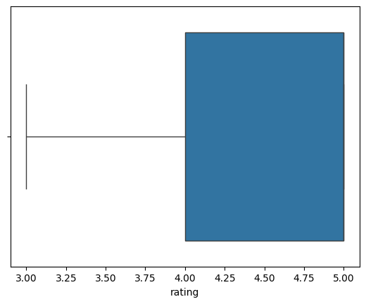

```python
# Doing a boxplot on the rating data to check if it is skewed or not
sns.boxplot(data=data,x='rating')
plt.show()
```

```python
# Going to use fillna to fill in the null rating values.
# Using transform to update all the rows with the median value.
# Grouping by restaurant name and then by cuisine_type to get the median only for that grouping to fill all the rows.
data['rating'] = data['rating'].fillna(value= data.groupby(['restaurant_name','cuisine_type'])['rating'].transform('median'))

# printing counts of null ratings after update
# Using dropna=False to get count of null values also
print(f"New value count of rating data is {data['rating'].value_counts(dropna=False)}")

# Using normalize=True to get the percentage counts.
print("\nPercentage value counts:")
data['rating'].value_counts(dropna=False,normalize=True)
```

```
New value count of rating data is rating
5.0    856
4.0    754
3.0    196
4.5     54
NaN     30
3.5      8
Name: count, dtype: int64

Percentage value counts:
```

| rating | proportion |
| --- | --- |
| 5.0 | 0.451001 |
| 4.0 | 0.397260 |
| 3.0 | 0.103267 |
| 4.5 | 0.028451 |
| NaN | 0.015806 |
| 3.5 | 0.004215 |

**dtype:** float64

```python
# Removing the rows with null data in the rating column
data.dropna(inplace=True)

# Converting rating column back to int
data['rating'] = data['rating'].astype(int)

#printing counts of null ratings after update
print(f"New value count of rating data is {data['rating'].value_counts(dropna=False)}")
```

```
New value count of rating data is rating
5    856
4    808
3    204
Name: count, dtype: int64
```

- *Now we see that we dont have any more null values in the data.*

### **Question 4:** Check the statistical summary of the data. What is the minimum, average, and maximum time it takes for food to be prepared once an order is placed? [2 marks]

```python
# Write your code here
# Using the describe function which will give a statistical summary of the data (including min, max, average, count and percentile values)
# for all the columns and then T for transposing the values
data.describe(include="all").T
```

|  | count | unique | top | freq | mean | std | min | 25% | 50% | 75% | max |
| --- | --- | --- | --- | --- | --- | --- | --- | --- | --- | --- | --- |
| order_id | 1868.0 | NaN | NaN | NaN | 1477495.074411 | 548.909169 | 1476547.0 | 1477019.75 | 1477492.5 | 1477973.25 | 1478444.0 |
| customer_id | 1868.0 | NaN | NaN | NaN | 170801.970021 | 113536.338875 | 1311.0 | 77544.0 | 128476.5 | 270444.0 | 405334.0 |
| restaurant_name | 1868 | 156 | Shake Shack | 219 | NaN | NaN | NaN | NaN | NaN | NaN | NaN |
| cuisine_type | 1868 | 14 | American | 579 | NaN | NaN | NaN | NaN | NaN | NaN | NaN |
| cost_of_the_order | 1868.0 | NaN | NaN | NaN | 16.512195 | 7.473723 | 4.47 | 12.08 | 14.16 | 22.2725 | 35.41 |
| day_of_the_week | 1868 | 2 | Weekend | 1325 | NaN | NaN | NaN | NaN | NaN | NaN | NaN |
| rating | 1868.0 | NaN | NaN | NaN | 4.349036 | 0.667731 | 3.0 | 4.0 | 4.0 | 5.0 | 5.0 |
| food_preparation_time | 1868.0 | NaN | NaN | NaN | 27.361349 | 4.628866 | 20.0 | 23.0 | 27.0 | 31.0 | 35.0 |
| delivery_time | 1868.0 | NaN | NaN | NaN | 24.185225 | 4.960147 | 15.0 | 20.0 | 25.0 | 28.0 | 33.0 |

#### Observations:

- *The minimum food preparation time is 20 minutes.*
- *The average food preparation time is 27.36 minutes (shown by mean value).*
- *The maximum food preparation time is 35 minutes.*
- *For 75% of the orders, food is prepared in 31 minutes or less.*

### **Question 5:** How many orders are not rated? [1 mark]

```python
# Write the code here
# In the beginning with the raw dataset, there were 736 rows have 'Not given' as the rating.

# I have imputed values for them now as part of Question no. 3
data['rating'].value_counts()
```

| rating | count |
| --- | --- |
| 5 | 856 |
| 4 | 808 |
| 3 | 204 |

**dtype:** int64

#### Observations:

- *In the beginning there were 736 orders which were not rated.*
- *I have imputed values for them now as part of Question no. 3 and also removed 30 of the rows which still contained null values for rating.*
- *So now we are left with no rows having orders which are not rated.*

### Exploratory Data Analysis (EDA)

### **Question 6:** Explore all the variables and provide observations on their distributions. (Generally, histograms, boxplots, countplots, etc. are used for univariate exploration.) [9 marks]

#### **Observations on CustomerId**

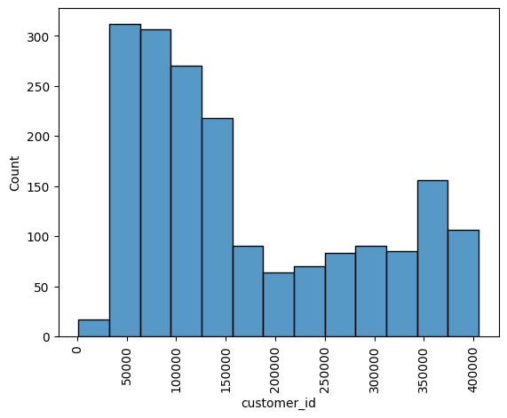

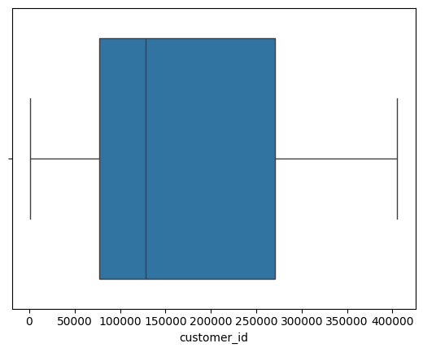

```python
# Write the code here
# Doing univariate analysis on the customer_id column
# Doing a histplot to get an idea of how many orders for various customers are present in the dataset
sns.histplot(data=data,x='customer_id')
plt.xticks(rotation = 90)
plt.show()
sns.boxplot(data=data,x='customer_id')
plt.show()
```

- *We have some customers who are repeat customers of this application which shows that many of them are interested in using the app.*
- *It would be interesting to see what food was ordered most by the repeat customers.*

#### **Observations on Cost of Order**

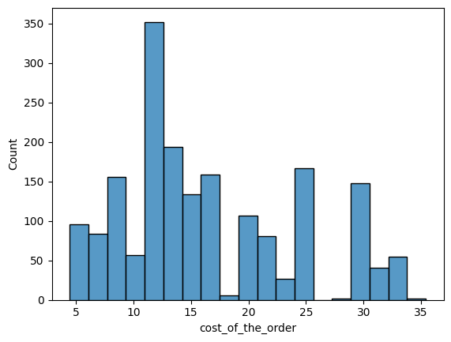

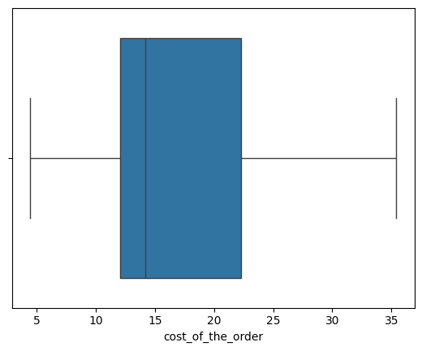

```python
# Doing univariate analysis on the cost_of_the_order column
# Doing a histplot to get an idea of how the cost is distributed
sns.histplot(data=data,x='cost_of_the_order')
plt.show()
sns.boxplot(data=data,x='cost_of_the_order')
plt.show()
```

- *The cost of orders ranges from around 4 to 35 dollars.*
- *50% of the orders have a cost of less than 15 dollars and 75% of the cost is less than 25 showing that most of the restaurants are not very high end ones.*
- *The boxplot shows that this column is slightly right skewed, but the data has no outliers.*

#### **Observations on Rating**

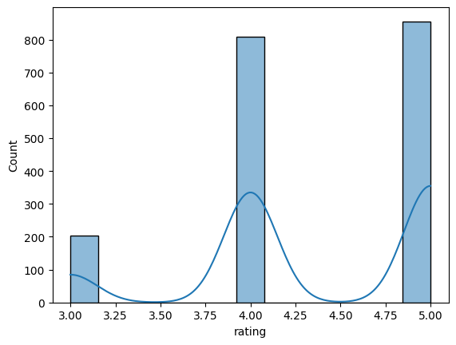

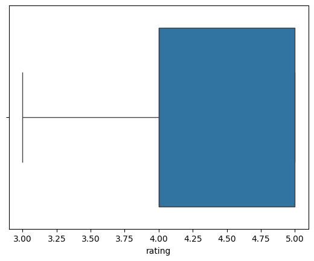

```python
# Doing univariate analysis on the rating column
# Doing a histplot to get an idea of how the rating is distributed in the dataset

sns.histplot(data=data,x='rating', kde=True)
plt.show()
sns.boxplot(data=data,x='rating')
plt.show()
```

#### **Observations on food preparation time**

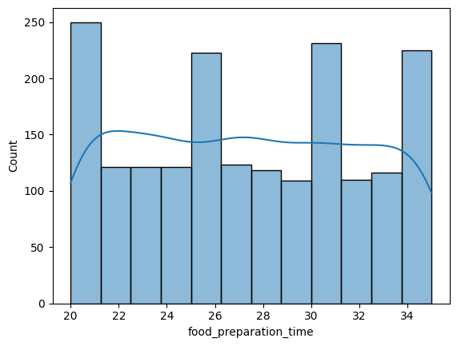

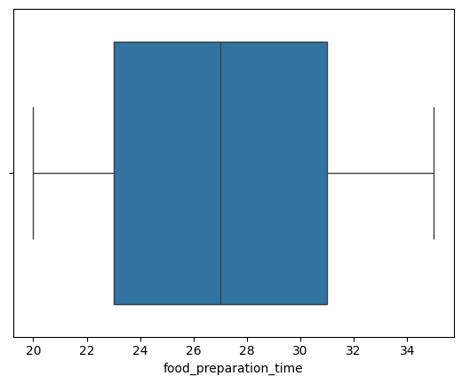

```python
# Doing univariate analysis on the food preparation time column
# Doing a histplot to get an idea of how the food preparation time is distributed in the dataset

sns.histplot(data=data,x='food_preparation_time', kde=True)
plt.show()
sns.boxplot(data=data,x='food_preparation_time')
plt.show()
```

- *We also see that food preparation time took approximately between 20 and 35 minutes for all the orders.*
- *We also see that food preparation time was less than or equal to 31 minutes for 75% of the orders.*
- *The data is not skewed and does not have any outliers.*
- *It will be interesting to see if this was due to less workers (due to weekends) or if it is based on the type of cuisine ordered.*

#### **Observations on delivery time**

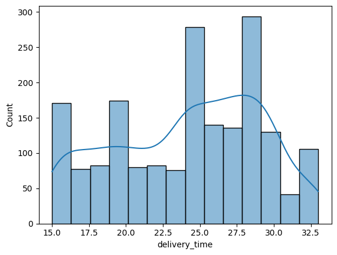

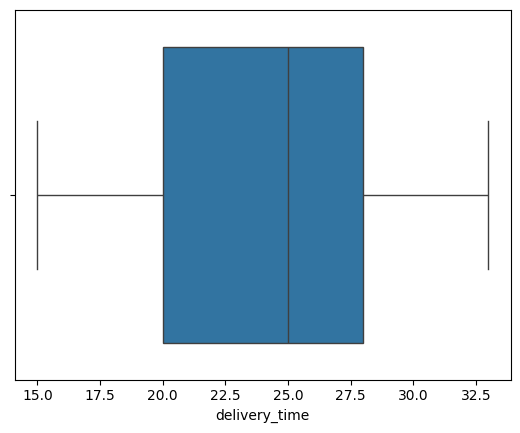

```python
# Doing univariate analysis on the delivery time column
# Doing a histplot to get an idea of how the delivery time is distributed in the dataset

sns.histplot(data=data,x='delivery_time', kde=True)
plt.show()
sns.boxplot(data=data,x='delivery_time')
plt.show()
```

- *We can observe that food delivery times vary between 15 and 33 minutes.*
- *We can observe that 75% of the orders are being delivered in around 28 minutes or less.*
- *This data is also slightly left skewed but there are no outliers in the delivery time.*
- *It would be interesting to see if deliveries are faster on weekends when hopefully traffic is ligther.*

#### **Observations on restaurant name**

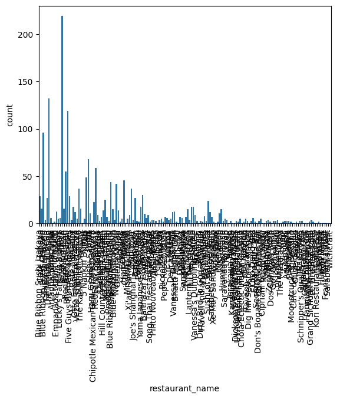

```python
# Using a countplot to see the distribution of restaurant name
# as this is a categorical column
sns.countplot(data=data,x='restaurant_name')
plt.xticks(rotation = 90);
```

```python
# Getting a count of the unique restaurants in the dataset
data['restaurant_name'].nunique()
```

```
156
```

```python
# Exploring how many restaurants have more than 1 order in the dataset
# with the number of orders for these restaurants.

# Storing the value counts for  restaurant name
# into a Series
name_value_counts = data['restaurant_name'].value_counts()

# print name and counts of orders for these restaurants
# Which have more than one order by filtering using counts > 1
name_value_counts[name_value_counts > 1]
```

| restaurant_name | count |
| --- | --- |
| Shake Shack | 219 |
| The Meatball Shop | 132 |
| Blue Ribbon Sushi | 119 |
| Blue Ribbon Fried Chicken | 96 |
| Parm | 68 |
| ... | ... |
| Xe May Sandwich Shop | 2 |
| Hot Kitchen | 2 |
| Zero Otto Nove | 2 |
| UVA Wine Bar & Restaurant | 2 |
| El Parador Cafe | 2 |

122 rows × 1 columns

**dtype:** int64

- *We can observe that there are 156 unique restaurants in this dataset.*
- *we also observe that customers have ordered multiple times from 122 restaurants in the dataset.*

#### **Observations on Cuisine Type**

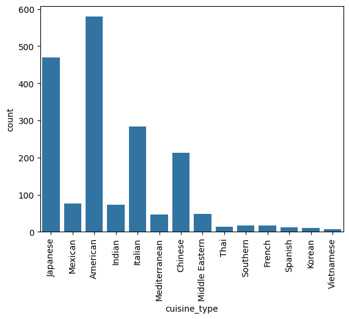

```python
# Using a countplot to see the distribution of cuisine type
# as this is a categorical column
sns.countplot(data=data,x='cuisine_type')
plt.xticks(rotation = 90);
```

- *We see that American followed by Japanese and then Italian are the most favorite cuisine types among the users of the app.*
- *We also see that Vietnamese seems to be the least favorite cuisine type among the users of the app.*

#### **Observations on Day of the week**

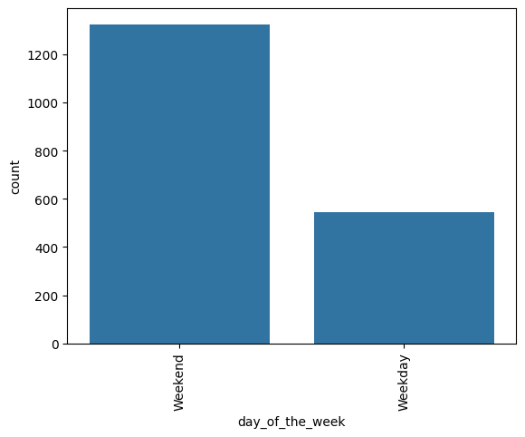

```python
# Using a countplot to see the distribution of day_of_the_week
# as this is a categorical column
sns.countplot(data=data,x='day_of_the_week')
plt.xticks(rotation = 90);
```

### **Question 7**: Which are the top 5 restaurants in terms of the number of orders received? [1 mark]

```python
# Write the code here
# Using value_counts() function which will group by the restaurant_name column and sorts descending by default and gives the counts.
# Since each row represents an order, this should give us the restaurants in descending order in terms of number of orders.
# Then using the head function to get the top 5 rows.
data['restaurant_name'].value_counts().head()
```

| restaurant_name | count |
| --- | --- |
| Shake Shack | 219 |
| The Meatball Shop | 132 |
| Blue Ribbon Sushi | 119 |
| Blue Ribbon Fried Chicken | 96 |
| Parm | 68 |

**dtype:** int64

#### Observations:

*The top 5 restaurants are*

- *Shake Shack*
- *The Meatball Shop*
- *Blue Ribbon Sushi*
- *Blue Ribbon Fried Chicken*
- *Parm*
- *The app owners could try to approach these restaurants asking them to advertise the app as a delivery recommendation in their restaurant as well as on the restaurant website.*
- *They could maybe reach some deal with these restaurants by giving them a percentage if more customers are reached through them.*

### **Question 8**: Which is the most popular cuisine on weekends? [1 mark]

```python
# Write the code here
# Using loc on the dataset and filtering on day of week as Weekend and cuisine_type as column and then using value_counts function
# to group the data on cuisine_type and get counts in descending order (default sort for value counts).
# Value_counts function returns a series with cuisine_type as the index
# Using first_valid_index() on this Series to get the first index which would be the cuisine type with the most counts.
# This shows that American is the most popular cuisine on weekends.

most_popular_cuisine = data.loc[data['day_of_the_week']=='Weekend', 'cuisine_type'].value_counts().first_valid_index()
print(f"Most popular cuisine is {most_popular_cuisine}" )
```

```
Most popular cuisine is American
```

#### Observations:

- *The most popular cuisine is American on weekends.*
- *The app owners could try to get more restaurants serving American cuisine onboard and this could help it get more customers to use the app as it seems to be the most favored cuisine.*

### **Question 9**: What percentage of the orders cost more than 20 dollars? [2 marks]

```python
# Write the code here
# We can get the count of rows with orders costing more than 20 using loc with the condition and column name (order_id) and applying the count function.
# Getting the total number of rows using shape[0]
# and dividing the count by total rows and multiplying by 100 to get percentage.

percent = data.loc[data['cost_of_the_order']>20, 'order_id'].count()/data.shape[0] * 100
print(f"Percentage of the orders costing more than 20 dollars is {percent}")
```

```
Percentage of the orders costing more than 20 dollars is 29.17558886509636
```

#### Observations:

- *Around 29% of the orders cost more than 20 dollars.*

### **Question 10**: What is the mean order delivery time? [1 mark]

```python
# Write the code here
#Using the mean function on the delivery_time column to get the mean order delivery time.
data['delivery_time'].mean()
```

```
np.float64(24.18522483940043)
```

#### Observations:

- *The mean order delivery time is around 24 minutes.*

### **Question 11:** The company has decided to give 20% discount vouchers to the top 3 most frequent customers. Find the IDs of these customers and the number of orders they placed. [1 mark]

```python
# Write the code here
# Using the value_counts function on the customer_id column gets the count of orders placed by each customer sorted in descending order of
# count of orders and using head with 3 as parameter to get first 3 most frequent customer ids and their counts.
data['customer_id'].value_counts().head(3)
```

| customer_id | count |
| --- | --- |
| 52832 | 13 |
| 47440 | 10 |
| 83287 | 9 |

**dtype:** int64

#### Observations:

*The top 3 customers and their order counts are*

- *Customer with id 52832 with 13 orders.*
- *Customer with id 47440 with 10 orders.*
- *Customer with id 83287 with 9 orders.*
- *This is a good idea as these customers could help get more of their acquaintances to use the app when they tell other people about them.*
- *The app company could also try to get new customers on their own by advertising about giving some discounts to new customers if they use the app for delivery.*

### **Question 12**: Perform a multivariate analysis to explore relationships between the important variables in the dataset. (It is a good idea to explore relations between numerical variables as well as relations between numerical and categorical variables) [10 marks]

#### **First doing a Correlation plot of the numerical columns by Heatmap**

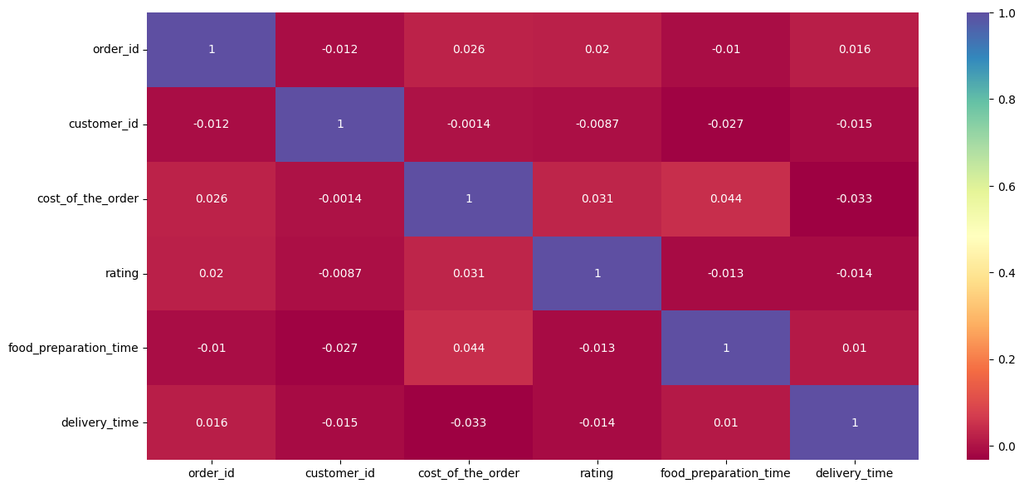

```python
# Getting the columns which are numeric from the dataset
num_var = data.dtypes[data.dtypes != 'object'].index

# Calculating the corelation between these numeric columns.
corr = data[num_var].corr(numeric_only = True)

# Setting size of the plot
plt.figure(figsize=(15, 7))

# Create heatmap and show
sns.heatmap(corr, annot=True, cmap="Spectral");
plt.show()
```

- *There is not much of a positive corelation between any of the numerical columns.*
- *We can observe that there is not much of a negative corelation either between any of the numerical columns.*

#### **Exploring co-relation between cost of order and rating**

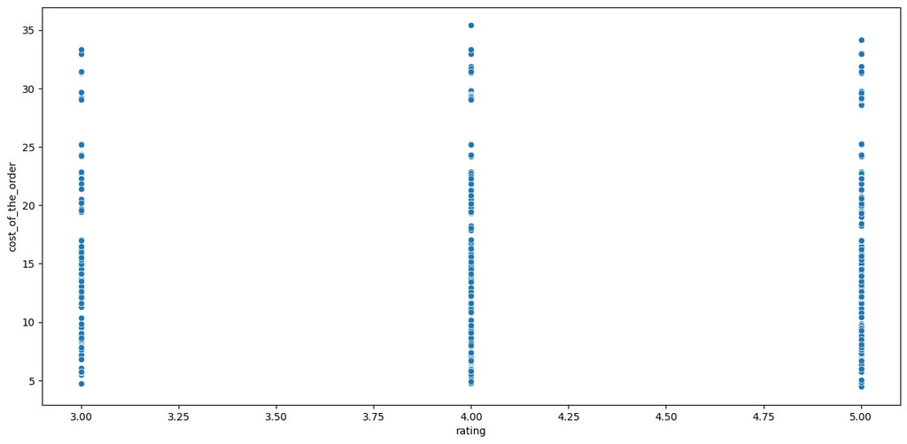

```python
# Using a scatterplot to explore this relationship
plt.figure(figsize=(15, 7))
sns.scatterplot(data=data, x='rating', y='cost_of_the_order')
#sns.jointplot(data=data, x='cost_of_the_order', y='rating', kind='hex')
#plt.colorbar(); # adds a separate axis indicating the color scale in this plot
plt.show()
```

- *There does not seem to be much of a relationship between cost of the order and rating.*
- *There seem to be 3,4 and 5 ratings in good concentration for lower costs and the counts are petering out as cost increases.*
- *This could just be that we dont have too many orders with costs above 25.*

[figure not shown]

```python
# To get another perspective on this, want to create some bins with cost values in increasing order
# so as to get an idea of rating for these price intervals
# Creating bins of price  0 to 15 as low, 15 to 25 as medium and 25 to 35 as high.
# Setting right parameter to False, so that the bins are left-inclusive and right-exclusive,
# meaning that the rightmost edge of each bin is not included in the bin, but would be included in the next bin.

data['cost_bins'] = pd.cut(data['cost_of_the_order'], bins=[0, 15, 25, 35], labels=['Low Price', 'Medium Price', 'High Price'], right=False)
plt.figure(figsize=(15, 7))
sns.boxplot(data=data, x='cost_bins', y='rating')
plt.show()
```

- *This boxplot also confirms that the ratings seem to be equally distributed across all prices.*

#### **Exploring relation between cost of order and food preparation time**

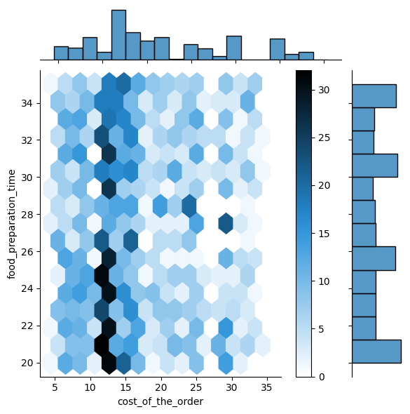

```python
# Using a jointplot to explore this relationship.
# Setting kind to hex to split plotting window into several hexagons
# The colour of each hexagon denotes the number of data points in it.
plt.figure(figsize=(15, 9))
sns.jointplot(data=data, x='cost_of_the_order', y='food_preparation_time', kind='hex')

# adds a separate axis indicating the color scale in this plot
plt.colorbar()
plt.show();
```

- *We observe that there are a lot of dark hexagons where cost of the order is between 10 and 15 dollars and food preparation time ranges from 20 to 26 minutes showing that there are many orders with this criteria in the dataset.*
- *There are also a couple of dark hexagons in the same cost range but with preparation time of around 30 and one around 31 minutes.*
- *This could indicate that many of the orders in the cost range of 12-15 dollars takes around 20-26 or 30-32 minutes to prepare.*

#### **Exploring relation between total delivery time (time for preparation + delivery time) and rating**

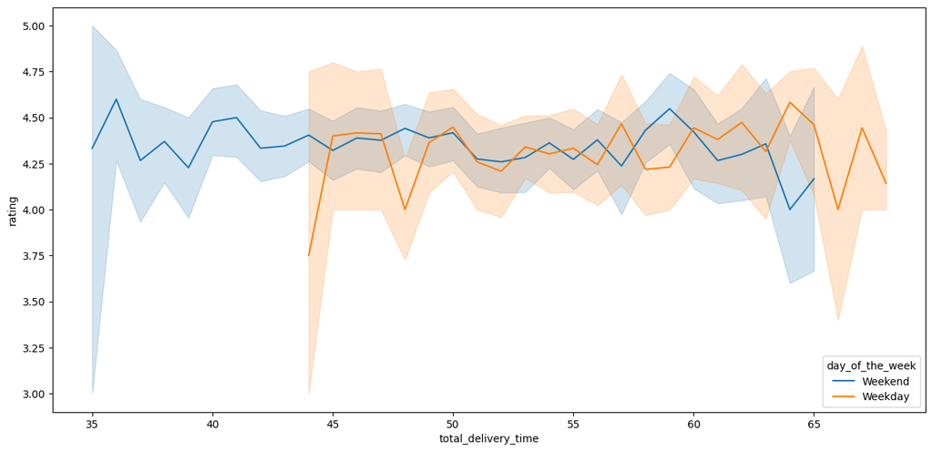

```python
# Using a line plot to explore this relation.
# Also setting hue to day of the week, to see if there is any change between weekdays and weekends.
data['total_delivery_time'] = data['food_preparation_time'] + data['delivery_time']
plt.figure(figsize=(15, 7))
sns.lineplot(x='total_delivery_time', y='rating', data=data, hue="day_of_the_week")
plt.show()
```

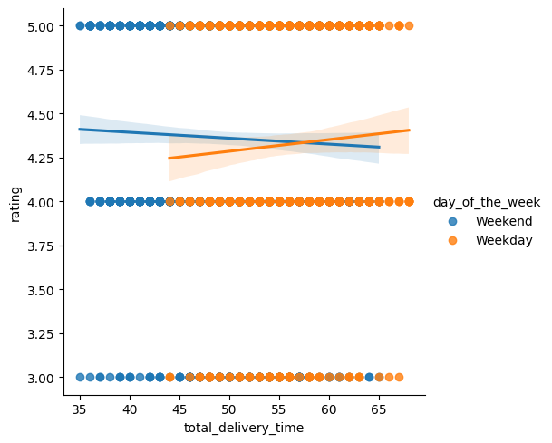

```python
# Exploring the same relationship with an lmplot to see the line of best fit
sns.lmplot(data = data, x = 'total_delivery_time', y = 'rating', hue='day_of_the_week')
```

#### **Checking relationship between cuisine type and day of week**

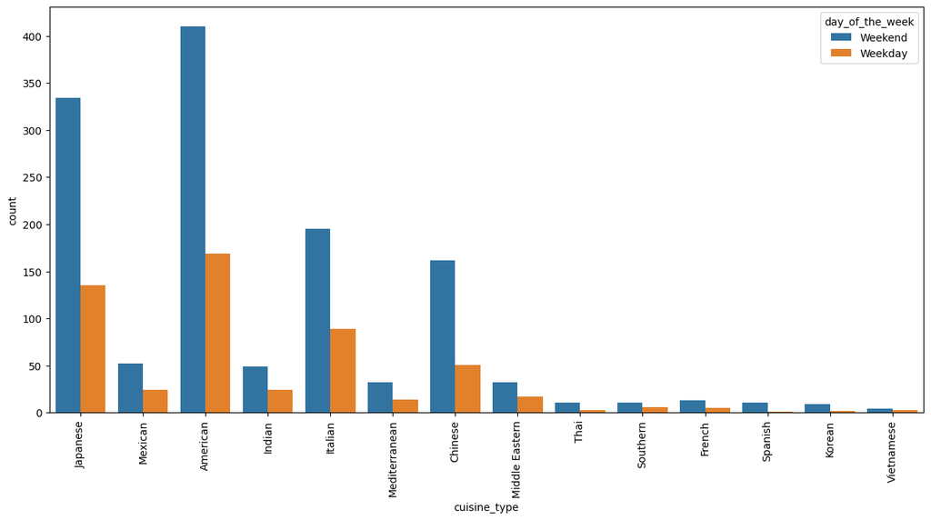

```python
# Using a countplot to explore this relationship
plt.figure(figsize=(15, 7))
plt.xticks(rotation=90)
sns.countplot(x='cuisine_type', hue='day_of_the_week', data=data)
plt.show()
```

#### **Exploring relationship between cuisine type and food preparation time**

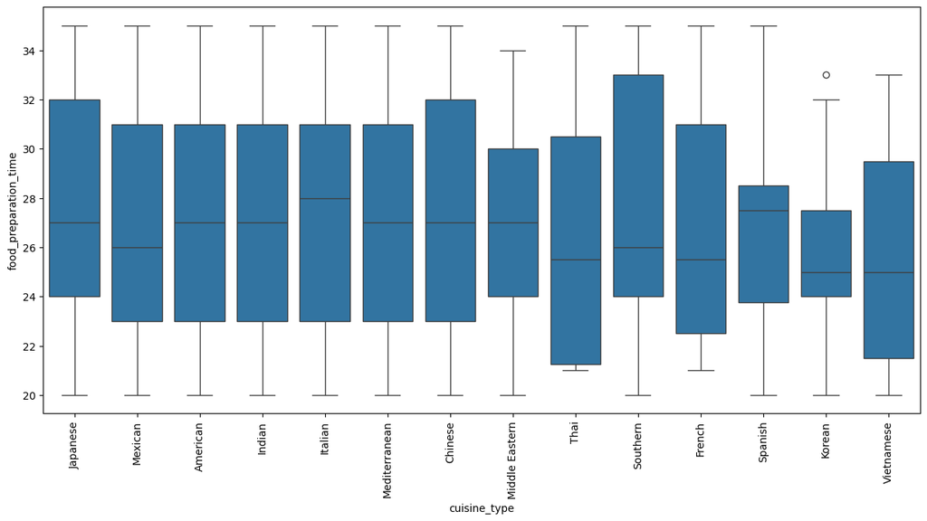

```python
# Using a boxplot to explore this relationship
plt.figure(figsize=(15, 7))
plt.xticks(rotation=90)
sns.boxplot(x='cuisine_type', y="food_preparation_time", data=data)
plt.show()
```

- *For most of the cuisine types, 75% of the orders have taken 32 minutes or less to prepare.*
- *Southern seems to be the exception where 75% of the orders took around 33 minutes or less to prepare.*
- *Korean seems to have an outlier with an order taking 33 minutes.*

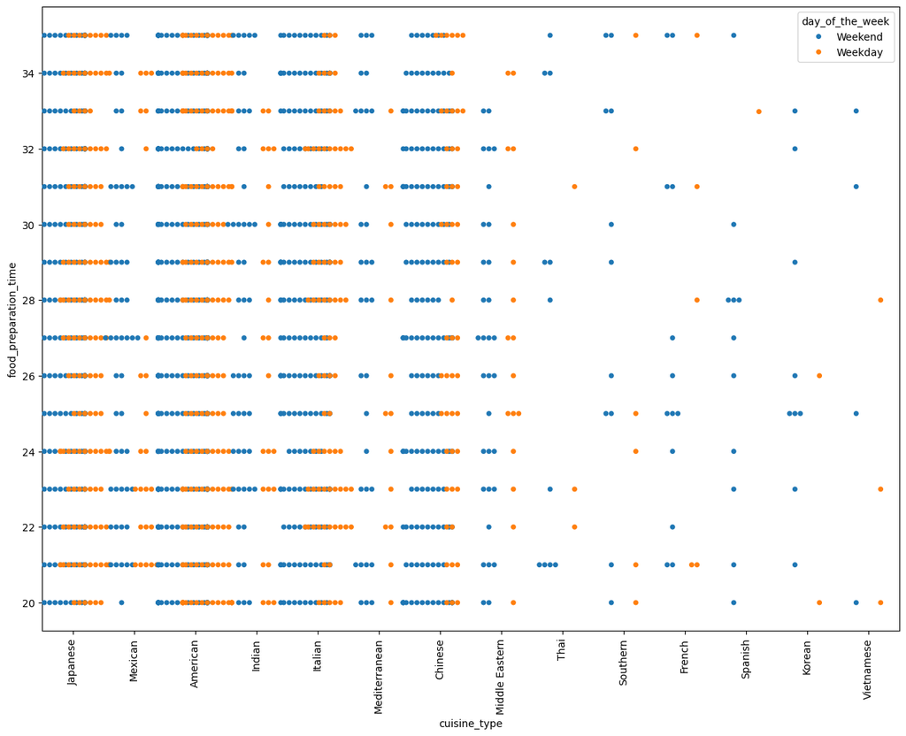

```python
# Using a swarm plot also to explore this relationship
# Adding day_of_the_Week as hue to see differences in weekday vs weekend

plt.figure(figsize=(15, 11))
plt.xticks(rotation=90)
sns.swarmplot(x='cuisine_type', y="food_preparation_time", data=data, hue="day_of_the_week", dodge=True)
plt.show();
```

- *We observe that there is not much of a difference in food preparation times between weekends and weekdays for all cuisine types.*
- *For the major cuisine types in the dataset (American, Japanese, Italian etc.), we do see food preparation times at the higher end of 35 minutes on both weekends and weekdays.*

#### **Exploring relationship between cuisine type and ratings**

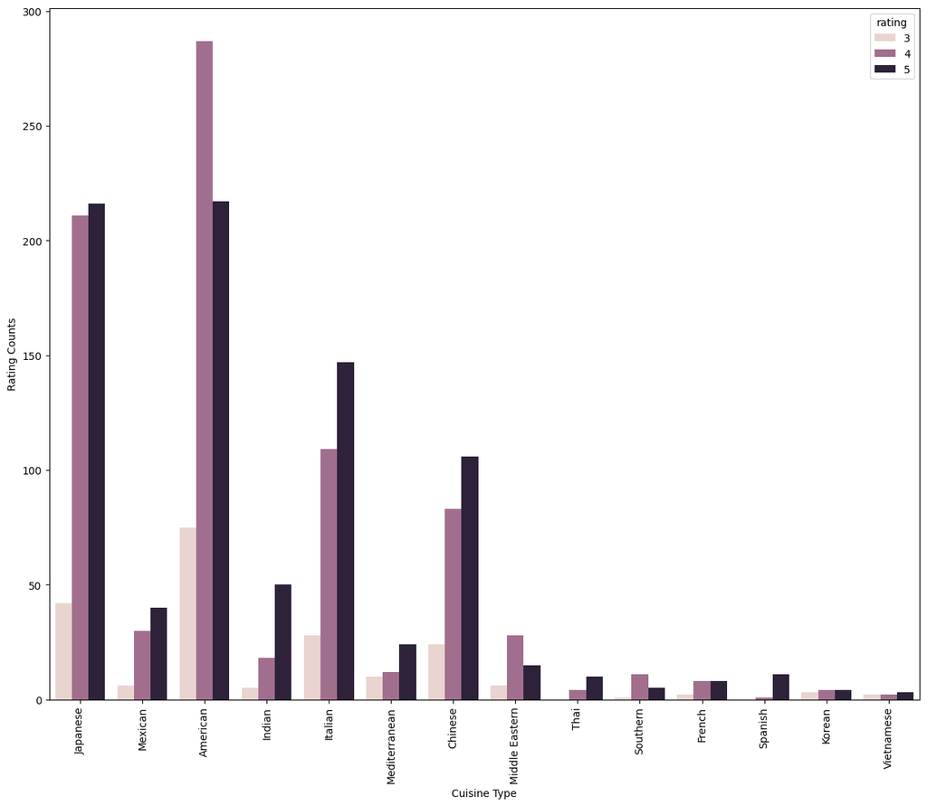

```python
# Using a countplot to explore this relationship
plt.figure(figsize=(15,12))
sns.countplot(data=data, x="cuisine_type", hue="rating")
plt.ylabel('Rating Counts')
plt.xlabel('Cuisine Type')
plt.xticks(rotation=90)
plt.show()
```

#### **Taking a look at the cuisine types ordered by repeat customers with more than 5 orders**

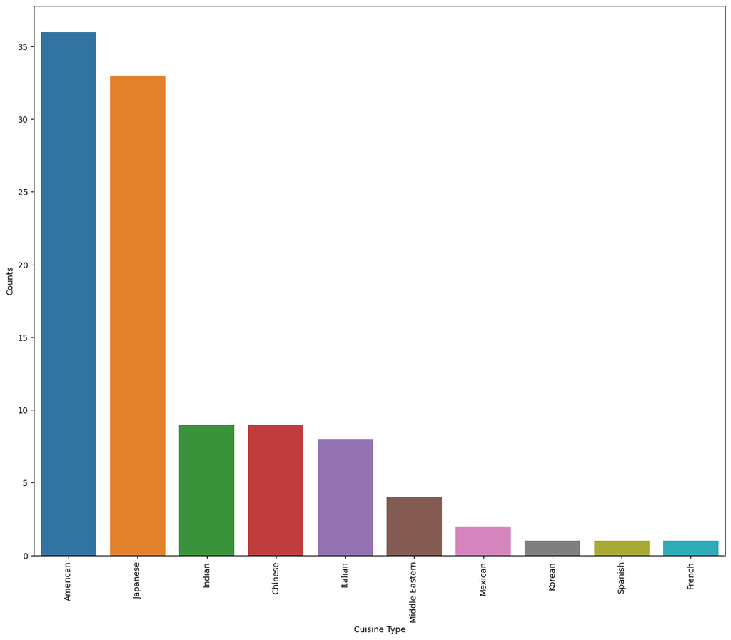

```python
# Using groupby to break the data by customer_id and then using transform with size > 5
# to get the data for customers with more than 5 orders
# and store this data into variable repeat_customer_data
repeat_customer_data = data.loc[data.groupby('customer_id').transform('size')>5]

# Creating a countplot to see what is the highest cuisine types ordered by these
# customers who have more than 5 orders in the data.
plt.figure(figsize=(15,12))
sns.countplot(data=repeat_customer_data, x="cuisine_type", hue="cuisine_type")
plt.ylabel('Counts')
plt.xlabel('Cuisine Type')
plt.xticks(rotation=90);
```

- *We observe that this trend of cuisine types also follows the trend of the larger dataset when cuisine types for all the orders were plotted.*
- *We see that American and Japanese are the two most favored cuisine types just as it was in the total dataset.*
- *We also observe that in the total dataset Italian was the 3 most favored cuisine, but here we have Indian and Chinese coming in third followed by Italian in 4th place.*

#### **Exploring relationship between cuisine type, cost of order, rating and day of the week using a catplot**

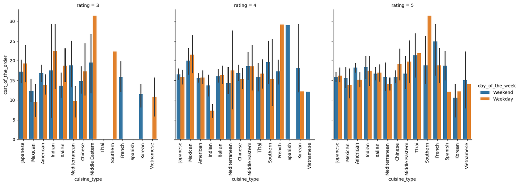

```python
# Using a bar catplot to explore cuisine_type, cost of order, with hue as day of the week and col as rating
g = sns.catplot(data=data, x="cuisine_type", y="cost_of_the_order", hue="day_of_the_week", col="rating", kind="bar")
g.set_xticklabels(rotation=90)
plt.show()
```

- *We observe that for Spanish and Thai cuisines, users never gave a 3 rating. They only got higher ratings of 4 and 5.*
- *We also observe that for Spanish, users ordering on weekdays, always gave a 5 rating.*
- *This could mean that users ordering Spanish were very happy with the overall experience and the food.*

#### **Exploring relationship between all the numerical columns using a pairplot**

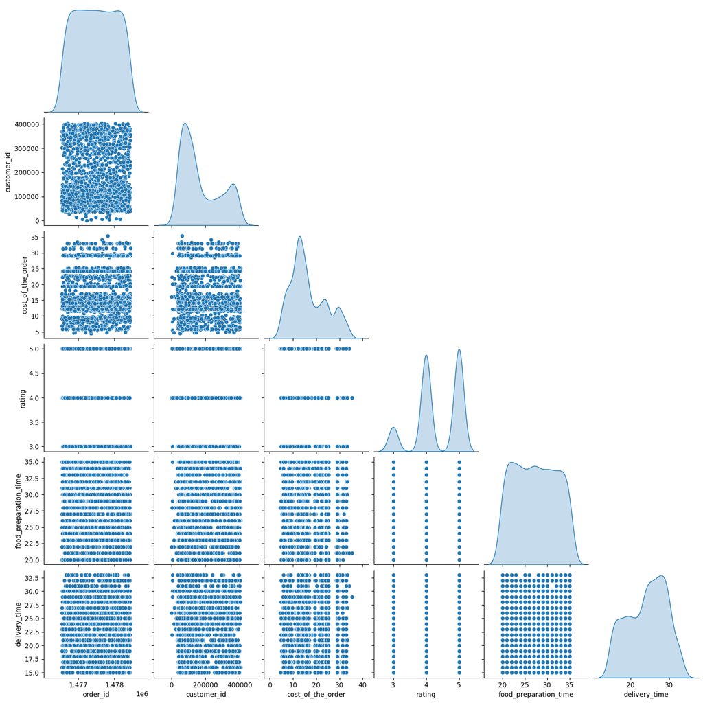

```python
sns.pairplot(data, diag_kind="kde", corner=True);
```

- *We dont observe any other corelation between the numerical columns.*

### **Question 13:** The company wants to provide a promotional offer in the advertisement of the restaurants. The condition to get the offer is that the restaurants must have a rating count of more than 50 and the average rating should be greater than 4. Find the restaurants fulfilling the criteria to get the promotional offer. [3 marks]

```python
# Write the code here

# Using  groupby to split the data by restaurant name and filtering the rows with restaurants which have
# more than 50 ratings and storing the rows for only those restaurants result in a temporary dataset data_with_ratings_above_50.
data_with_ratings_above_50 = data.groupby('restaurant_name').filter(lambda x: x['rating'].count() > 50)

# Running groupby on restaurant_name on this new dataset to split by restaurant_name again and get restaurants with average rating above 4
# into a Series called final_dataset.
final_dataset = data_with_ratings_above_50.groupby('restaurant_name')['rating'].mean()>4

# Printing just the index of this series which would be just the restaurant names
print(final_dataset.index.to_list())
```

```
['Blue Ribbon Fried Chicken', 'Blue Ribbon Sushi', 'Parm', 'RedFarm Broadway', 'RedFarm Hudson', 'Shake Shack', 'The Meatball Shop']
```

#### Observations:

*The restaurants with more than 50 ratings and average rating more than 4 are*

- *Blue Ribbon Fried Chicken*
- *Blue Ribbon Sushi*
- *Parm*
- *RedFarm Broadway*
- *RedFarm Hundson*
- *Shake Shack*
- *The Meatball Shop*

*The app company could also try to get a deal with these restaurants to advertise the app on their websites as well as in the restaurant for delivery options for the customers.*

### **Question 14:** The company charges the restaurant 25% on the orders having cost greater than 20 dollars and 15% on the orders having cost greater than 5 dollars. Find the net revenue generated by the company across all orders. [3 marks]

```python
# Write the code here
# Created a function revenue to get the revenue based on the cost of the order
def revenue(order_cost):
  if order_cost > 20:
    return order_cost*0.25
  elif order_cost > 5:
    return order_cost*0.15
  else:
    return

# Using the apply function to apply revenue method to cost of the order on each row
# and store the revenue returned by the function in a new column called revenue in the dataset
data['revenue'] = data['cost_of_the_order'].apply(revenue)
print(f"Net revenue generated by company is {data['revenue'].sum()} dollars.")
```

```
Net revenue generated by company is 6069.882 dollars.
```

#### Observations:

- *Total net revenue due to this charge is 6069.88 dollars.*

### **Question 15:** The company wants to analyze the total time required to deliver the food. What percentage of orders take more than 60 minutes to get delivered from the time the order is placed? (The food has to be prepared and then delivered.) [2 marks]

```python
# Write the code here
# Getting the rows where total delivery tiem is greater than 60 miinutes by using loc function and adding the columns delivery_time and food_preparation_time and checking that the total time is greater than 60
# Using count function to get the total number of rows where the such time is greater than 60
# Then for these rows, we are dividing by the count by the first value of the shape attribute which contains the total number of rows in the dataset and then
# multiplying by 100 to get the percentage of orders where total delivery time is greater than 60.

percent = data.loc[data['delivery_time'] + data['food_preparation_time'] > 60 ,'order_id'].count() / data.shape[0] * 100
print(f"Percentage of orders take more than 60 minutes to get delivered is {percent}")
```

```
Percentage of orders take more than 60 minutes to get delivered is 10.546038543897216
```

#### Observations:

- *The Percentage of orders that take more than 60 minutes to get delivered is 10.54.*
- *The app owners could consider getting some app like waze which optimizes travel routes based on traffic efficiently.*
- *The owners could get their delivery people to use this app to speed up delivery times.*

### **Question 16:** The company wants to analyze the delivery time of the orders on weekdays and weekends. How does the mean delivery time vary during weekdays and weekends? [2 marks]

```python
# Write the code here
# Using groupby to split the data based on day_of_the_week column and then by delivery time
# The using the mean function to get the mean delivery_time for weekdays and weekends
percent = data.groupby('day_of_the_week')['delivery_time'].mean()
print(f"Delivery time mean by day of the week: {percent}")
```

```
Delivery time mean by day of the week: day_of_the_week
Weekday    28.329650
Weekend    22.486792
Name: delivery_time, dtype: float64
```

#### Observations:

- *The mean delivery time during weekdays is 28.329650 minutes.*
- *The mean delivery time during weekends is 22.486792 minutes.*
- *The mean delivery time is faster by 5.84 minutes on weekends as compared to weekdays.*
- *This could be due to the fact that the traffic is less on weekends compared to weekdays.*

### Recommendations:

- *The app should also put in a feedback box with the rating, where the customer could type in why they gave the rating, so that we could get more details on the criteria for the rating. This feedback would be valuable in the improvements we need to consider for the app. This will help us understand if the feedback was based on the food or the total delivery time or on ease of using the app etc.*
- *The app company should consider getting deals with more of restaurants serving American, Japanese and Italian which have high orders and feedback ratings from the existing customers. This will give them more choice and might bring them to use the app for more orders.*
- *The app company should consider promoting/advertising restaurants with Vietnamese, Korean and other cuisine types with lower feedback ratings to get more customers ordering these cuisines.*
- *They could also consider doing more TV advertisements in these neighborhoods where there are many of these restaurants with these low feedback cuisine types to get more customers from these neighbourhoods.*
- *The company should give promotional vouchers to customers using the app many times.*
- *The company should consider giving discounts to customers who bring in new customers to use the app by referral.*
- *The app company could also do the same with restaurants by charging them less surcharge, if they get more customers to use the app by advertising about the app in their physical restaurant buildings.*
- *The app company could try out printing physical vouchers for new customers and getting the restaurants to display them and allow customers to take them, which might get new customers who usually go to the restaurant to start using the app for orders.*
- *The company could invest in a more efficient navigation app like waze by doing a study to check if it improves delivery times and if so get it as its standard navigation app for its delivery employees, thus improving delivery times.*
- *Since we see that most of the orders came on weekends, the company could try promotions like reduced delivery fee on the app on certain weekdays to get more orders from customers on weekdays.*
- *The company can do more promotions of restaurants with high feedback ratings on their website.*